# Regression Battleship Tips and Tricks

```r
library(pander)
```

# What it means to “Hide a Model”

## Two-lines model

$$Y_i = \beta_0 + \beta_1 X_{1i} + \beta_2 X_{2i} + \beta_3 X_{1i}
X_{2i} + \epsilon_i \quad \text{where} \ \epsilon_i \sim N(0,\sigma^2)
\\
X_{2i} = \left\{\begin{array}{ll}
0, & \text{Group 1} \\
1, & \text{Group 2} \\
\end{array}\right.$$
Let’s look at three different applications of this model. Even though these are all two-lines models, some models are harder to find with the pairs plot than other models. Compare each of these. Study how they were made and what is different about them. Learn what makes a model hard to find.

### Easy to Find

#### Desmos

[figure not shown]

#### R Plot

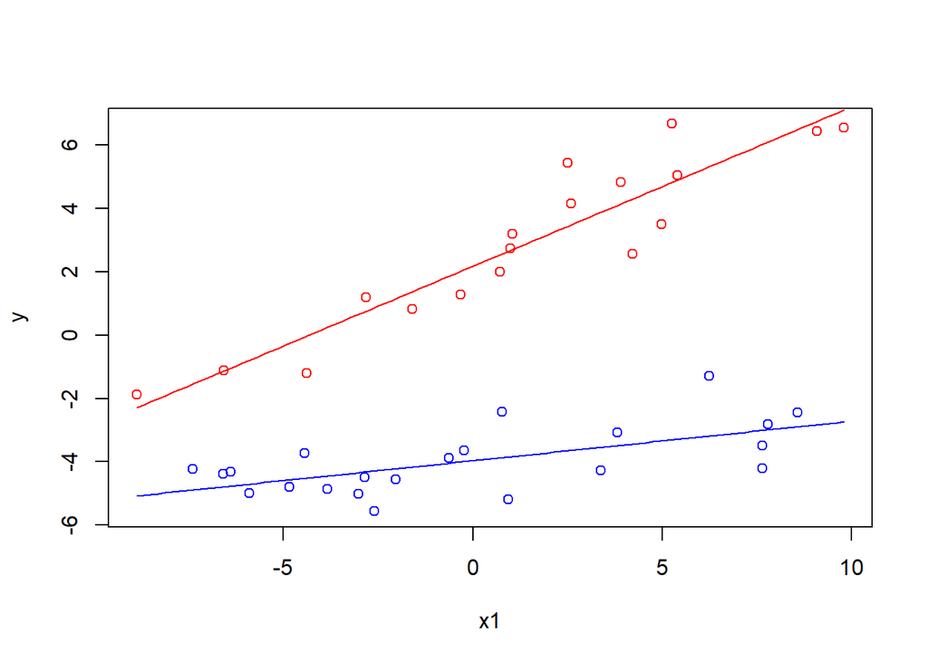

```r
set.seed(100)

n <- 40

x1 <- runif(n, -10, 10) #true x-axis variable
x2 <- rchisq(n, 3) #garbage
x3 <- sample(c(0,1), n, replace=TRUE) #true on-off switch
x4 <- sample(c(0,1), n, replace=TRUE) #garbage
x5 <- rf(n, 2, 3) #garbage

#Use red line as base line:
beta0 <- 2
beta1 <- 0.5

#These give the changes needed to achieve the blue line
beta2 <- -6 #(beta0 + beta2 = -4)
beta3 <- -0.4 #(beta1 + beta3 = 0.1)

sigma <- 0.8

#Required to have normally distributed error terms
epsilon_i <- rnorm(n, 0, sigma)

y <- beta0 + beta1*x1 + beta2*x3 + beta3*x1*x3 + epsilon_i

rbdata <- data.frame(y, x1, x2, x3, x4, x5)

palette(c("red","blue"))
plot(y ~ x1, data=rbdata, col=as.factor(x3))
truelm <- lm(y ~ x1 + x3 + x1:x3, data=rbdata)
b <- coef(truelm)
x3=0
curve(b[1] + b[2]*x1 + b[3]*x3 + b[4]*x1*x3, xname="x1", add=TRUE, col="red")
x3=1
curve(b[1] + b[2]*x1 + b[3]*x3 + b[4]*x1*x3, xname="x1", add=TRUE, col="blue")
```

```r
summary(truelm)
```

```
##
## Call:
## lm(formula = y ~ x1 + x3 + x1:x3, data = rbdata)
##
## Residuals:
##      Min       1Q   Median       3Q      Max
## -1.72877 -0.56070  0.04655  0.44216  2.00120
##
## Coefficients:
##             Estimate Std. Error t value Pr(>|t|)
## (Intercept)  2.17327    0.22633   9.602 1.82e-11 ***
## x1           0.50314    0.04476  11.241 2.49e-13 ***
## x3          -6.13616    0.29965 -20.478  < 2e-16 ***
## x1:x3       -0.37806    0.05892  -6.417 1.94e-07 ***
## ---
## Signif. codes:  0 '***' 0.001 '**' 0.01 '*' 0.05 '.' 0.1 ' ' 1
##
## Residual standard error: 0.9205 on 36 degrees of freedom
## Multiple R-squared:  0.9504, Adjusted R-squared:  0.9463
## F-statistic: 230.2 on 3 and 36 DF,  p-value: < 2.2e-16
```

#### Pairs Plot

Notice how obvious it is that x3 matters and that x1 has two separate lines showing in it.

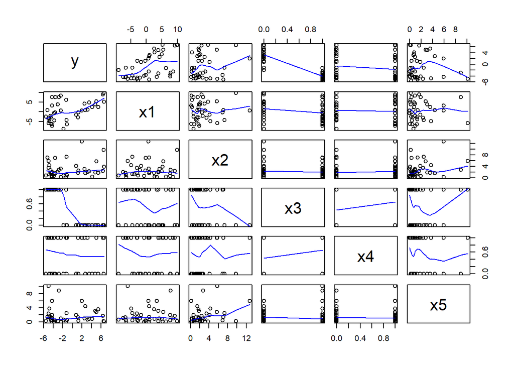

```r
pairs(rbdata, panel=panel.smooth)
```

### Better

#### Desmos

[figure not shown]

#### R Plot

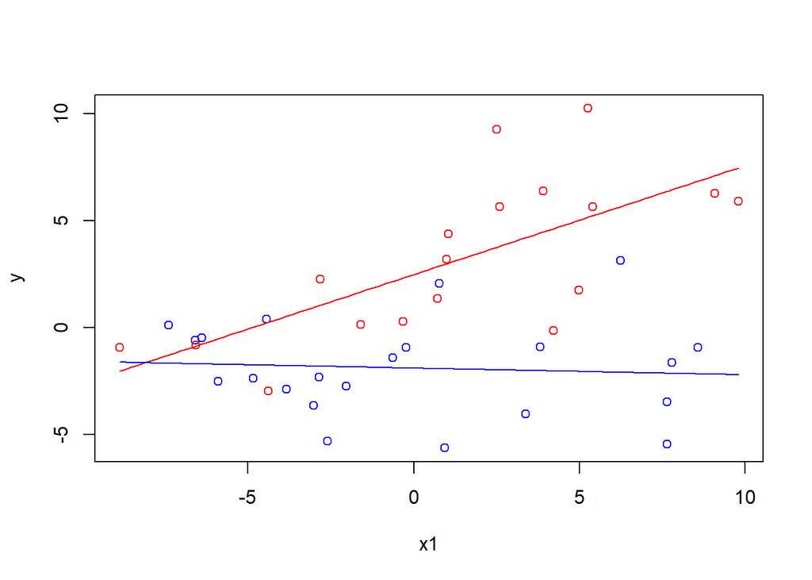

```r
set.seed(100)

n <- 40

x1 <- runif(n, -10, 10) #true x-axis variable
x2 <- rchisq(n, 3) #garbage
x3 <- sample(c(0,1), n, replace=TRUE) #true on-off switch
x4 <- sample(c(0,1), n, replace=TRUE) #garbage
x5 <- rf(n, 2, 3) #garbage

#Use red line as base line:
beta0 <- 2
beta1 <- 0.5

#These give the changes needed to achieve the blue line
beta2 <- -4 #(beta0 + beta2 = -2)
beta3 <- -0.6 #(beta1 + beta3 = -0.1)

sigma <- 2.2

#Required to have normally distributed error terms
epsilon_i <- rnorm(n, 0, sigma)

y <- beta0 + beta1*x1 + beta2*x3 + beta3*x1*x3 + epsilon_i

rbdata <- data.frame(y, x1, x2, x3, x4, x5)

palette(c("red","blue"))
plot(y ~ x1, data=rbdata, col=as.factor(x3))
truelm <- lm(y ~ x1 + x3 + x1:x3, data=rbdata)
b <- coef(truelm)
x3=0
curve(b[1] + b[2]*x1 + b[3]*x3 + b[4]*x1*x3, xname="x1", add=TRUE, col="red")
x3=1
curve(b[1] + b[2]*x1 + b[3]*x3 + b[4]*x1*x3, xname="x1", add=TRUE, col="blue")
```

```r
summary(truelm)
```

```
##
## Call:
## lm(formula = y ~ x1 + x3 + x1:x3, data = rbdata)
##
## Residuals:
##    Min     1Q Median     3Q    Max
## -4.754 -1.542  0.128  1.216  5.503
##
## Coefficients:
##             Estimate Std. Error t value Pr(>|t|)
## (Intercept)   2.4765     0.6224   3.979 0.000321 ***
## x1            0.5086     0.1231   4.132 0.000204 ***
## x3           -4.3745     0.8240  -5.309 5.84e-06 ***
## x1:x3        -0.5397     0.1620  -3.331 0.002011 **
## ---
## Signif. codes:  0 '***' 0.001 '**' 0.01 '*' 0.05 '.' 0.1 ' ' 1
##
## Residual standard error: 2.531 on 36 degrees of freedom
## Multiple R-squared:  0.6144, Adjusted R-squared:  0.5822
## F-statistic: 19.12 on 3 and 36 DF,  p-value: 1.385e-07
```

#### Pairs Plot

Notice how obvious it is that x3 matters, even though x1 is fairly well hidden.

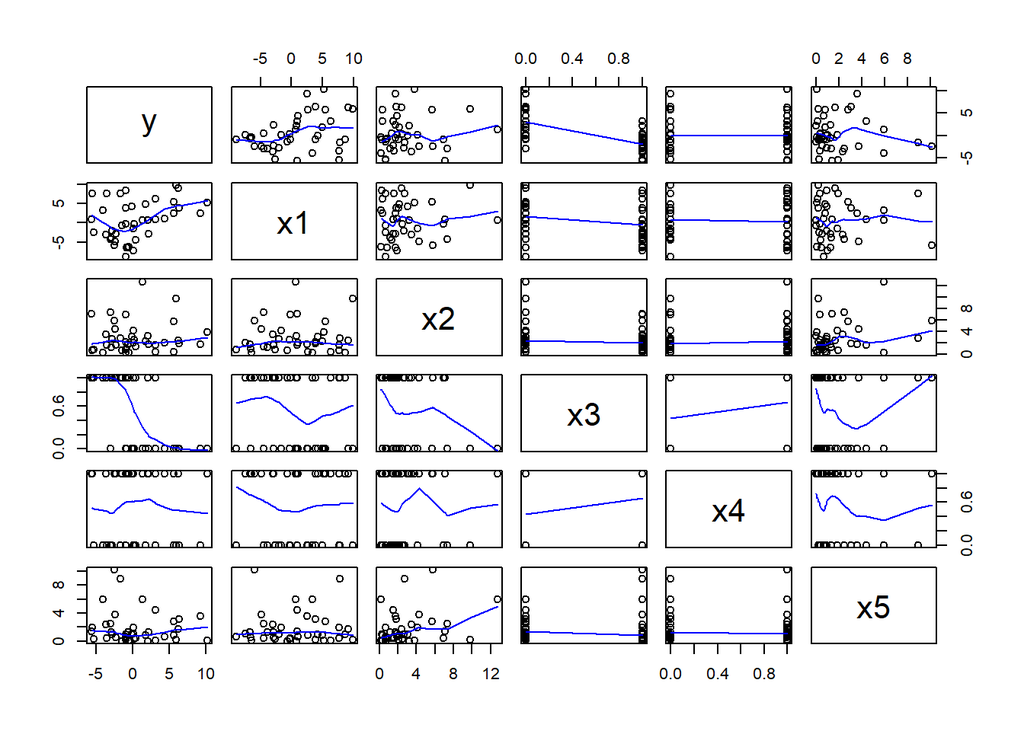

```r
pairs(rbdata, panel=panel.smooth)
```

### Well Hidden

#### Desmos

[figure not shown]

#### R Plot

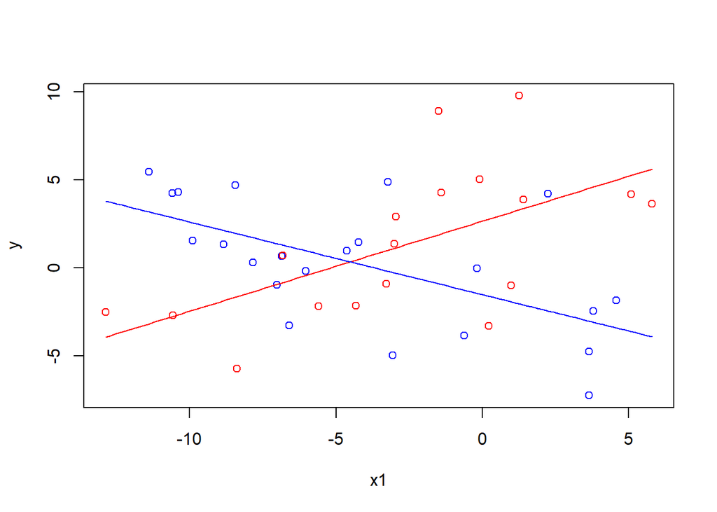

```r
set.seed(100)

n <- 40

x1 <- runif(n, -14, 6) #true x-axis variable
x2 <- rchisq(n, 3) #garbage
x3 <- sample(c(0,1), n, replace=TRUE) #true on-off switch
x4 <- sample(c(0,1), n, replace=TRUE) #garbage
x5 <- rf(n, 2, 3) #garbage

#Use red line as base line:
beta0 <- 2
beta1 <- 0.5

#These give the changes needed to achieve the blue line
beta2 <- -4 #(beta0 + beta2 = -2)
beta3 <- -1 #(beta1 + beta3 = -0.5)

sigma <- 2.8

#Required to have normally distributed error terms
epsilon_i <- rnorm(n, 0, sigma)

y <- beta0 + beta1*x1 + beta2*x3 + beta3*x1*x3 + epsilon_i

rbdata <- data.frame(y, x1, x2, x3, x4, x5)

palette(c("red","blue"))
plot(y ~ x1, data=rbdata, col=as.factor(x3))
truelm <- lm(y ~ x1 + x3 + x1:x3, data=rbdata)
b <- coef(truelm)
x3=0
curve(b[1] + b[2]*x1 + b[3]*x3 + b[4]*x1*x3, xname="x1", add=TRUE, col="red")
x3=1
curve(b[1] + b[2]*x1 + b[3]*x3 + b[4]*x1*x3, xname="x1", add=TRUE, col="blue")
```

```r
summary(truelm)
```

```
##
## Call:
## lm(formula = y ~ x1 + x3 + x1:x3, data = rbdata)
##
## Residuals:
##     Min      1Q  Median      3Q     Max
## -6.0507 -1.9625  0.1629  1.5476  7.0042
##
## Coefficients:
##             Estimate Std. Error t value Pr(>|t|)
## (Intercept)   2.6504     0.8589   3.086  0.00389 **
## x1            0.5110     0.1567   3.262  0.00243 **
## x3           -4.1695     1.2346  -3.377  0.00177 **
## x1:x3        -0.9232     0.2062  -4.477 7.34e-05 ***
## ---
## Signif. codes:  0 '***' 0.001 '**' 0.01 '*' 0.05 '.' 0.1 ' ' 1
##
## Residual standard error: 3.222 on 36 degrees of freedom
## Multiple R-squared:  0.3719, Adjusted R-squared:  0.3196
## F-statistic: 7.107 on 3 and 36 DF,  p-value: 0.0007184
```

#### Pairs Plot

The pairs plot doesn’t really show that x1 or x3 matter. They are both well hidden. If anything, x4 almost looks like it should matter, but it doesn’t. So this would be a hard model to find, even though it is just a basic two-lines model.

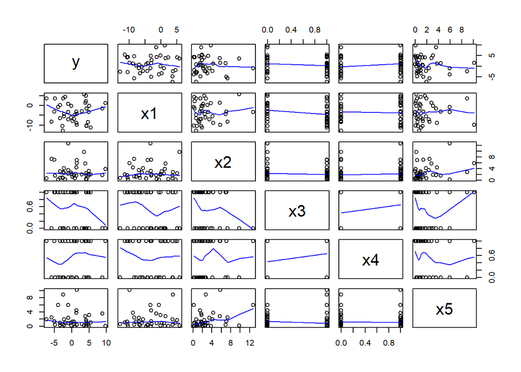

```r
pairs(rbdata, panel=panel.smooth)
```

## Four-lines model

$$Y_i = \beta_0 + \beta_1 X_{1i} + \text{(baseline)} \\
\beta_2 X_{2i} + \beta_3 X_{1i} X_{2i} + \text{(adjustments for x2
line)}\\
\beta_4 X_{3i} + \beta_5 X_{1i} X_{3i} + \text{(adjustments for x3
line)}\\
\beta_6 X_{2i} X_{3i} + \beta_7 X_{1i} X_{2i} X_{3i} +
\text{(adjustments for x2:x3 combo line)} + \epsilon_i \\
\quad \text{where} \ \epsilon_i \sim N(0,\sigma^2) \\
X_{2i} = \left\{\begin{array}{ll}
0, & \text{Group 1 of Factor 1} \\
1, & \text{Group 2 of Factor 1} \\
\end{array}\right. \text{and} \ X_{3i} = \left\{\begin{array}{ll}
0, & \text{Group 1 of Factor 2} \\
1, & \text{Group 2 of Factor 2} \\
\end{array}\right.$$

### Good

#### Desmos

[figure not shown]

#### R Plot

```r
set.seed(100)

n <- 80

x1 <- runif(n, -14, 6) #true x-axis variable
x2 <- rchisq(n, 3) #garbage
x3 <- sample(c(0,1), n, replace=TRUE) #true on-off switch
x4 <- sample(c(0,1), n, replace=TRUE) #true on-off switch
x5 <- rf(n, 2, 3) #garbage

#Use red line as base line:
beta0 <- 2
beta1 <- 0.5

#These give the changes needed to achieve the blue line
beta2 <- -4 #(beta0 + beta2 = -2)
beta3 <- -1 #(beta1 + beta3 = -0.5)

#These give the changes needed to achieve the green line
beta4 <- 1 #(beta0 + beta4 = 3)
beta5 <- -0.4 #(beta1 + beta5 = 0.1)

#These give the changes needed to achieve the purple line
beta6 <- -3 #(beta0 + beta2 + beta4 + beta6 = -4)
beta7 <- 0.7 #(beta1 + beta3 + beta5 + beta7 = -0.2)


sigma <- 0.8

#Required to have normally distributed error terms
epsilon_i <- rnorm(n, 0, sigma)

y <- beta0 + beta1*x1 +
  beta2*x3 + beta3*x1*x3 +
  beta4*x4 + beta5*x1*x4 +
  beta6*x3*x4 + beta7*x1*x3*x4 + epsilon_i

rbdata <- data.frame(y, x1, x2, x3, x4, x5)

palette(c("red2","steelblue3","green4","purple3"))
plot(y ~ x1, data=rbdata, col=interaction(x3,x4))
truelm <- lm(y ~ x1 +
               x3 + x1:x3 +
               x4 + x1:x4 +
               x3:x4 + x3:x4:x1, data=rbdata)
b <- coef(truelm)
b
```

```
## (Intercept)          x1          x3          x4       x1:x3       x1:x4
##   2.1854698   0.5051762  -3.4517577   0.9780854  -0.8965730  -0.3837752
##       x3:x4    x1:x3:x4
##  -3.6326101   0.5657443
```

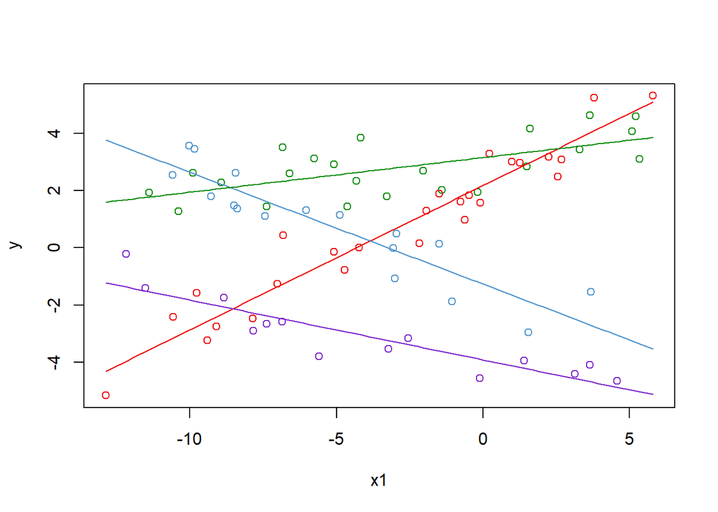

```r
drawit <- function(x3=0,x4=0, color="black"){
  curve(b[1] + b[2]*x1 + b[3]*x3 + b[4]*x4 + b[5]*x1*x3 + b[6]*x1*x4 + b[7]*x3*x4 + b[8]*x1*x3*x4, xname="x1", add=TRUE, col=color)
}

drawit(x3=0, x4=0, color="red2")
drawit(x3=1, x4=0, color="steelblue3")
drawit(x3=0, x4=1, color="green4")
drawit(x3=1, x4=1, color="purple3")
```

```r
summary(truelm)
```

```
##
## Call:
## lm(formula = y ~ x1 + x3 + x1:x3 + x4 + x1:x4 + x3:x4 + x3:x4:x1,
##     data = rbdata)
##
## Residuals:
##      Min       1Q   Median       3Q      Max
## -1.19938 -0.58701  0.07262  0.51771  1.68857
##
## Coefficients:
##             Estimate Std. Error t value Pr(>|t|)
## (Intercept)  2.18547    0.16838  12.979  < 2e-16 ***
## x1           0.50518    0.02947  17.143  < 2e-16 ***
## x3          -3.45176    0.33431 -10.325 7.51e-16 ***
## x4           0.97809    0.24421   4.005 0.000149 ***
## x1:x3       -0.89657    0.05200 -17.240  < 2e-16 ***
## x1:x4       -0.38378    0.04198  -9.142 1.14e-13 ***
## x3:x4       -3.63261    0.44870  -8.096 1.02e-11 ***
## x1:x3:x4     0.56574    0.07016   8.064 1.16e-11 ***
## ---
## Signif. codes:  0 '***' 0.001 '**' 0.01 '*' 0.05 '.' 0.1 ' ' 1
##
## Residual standard error: 0.7394 on 72 degrees of freedom
## Multiple R-squared:  0.9321, Adjusted R-squared:  0.9255
## F-statistic: 141.3 on 7 and 72 DF,  p-value: < 2.2e-16
```

#### Pairs Plot

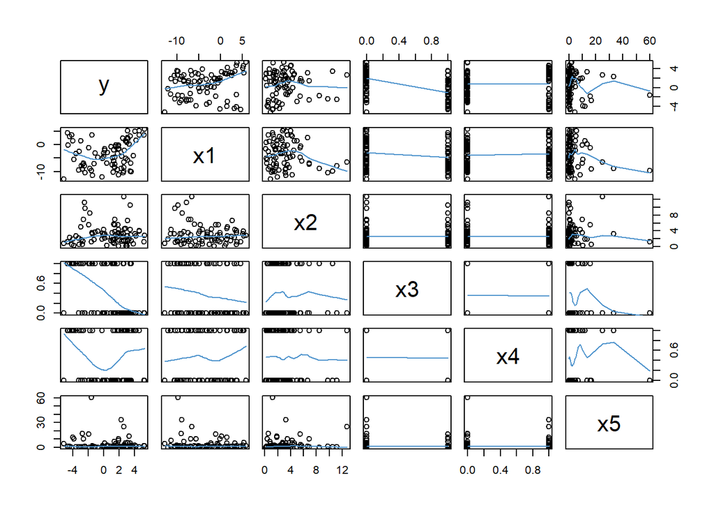

```r
pairs(rbdata, panel=panel.smooth)
```

### Well Hidden

What would need to happen to the Desmos plot to make this become really well hidden? Hint, think about what the pairs plot in the Good example easily gave away and how you could hide that.